# Statistical rethinking assignements - Chapter 2

Deportivo Bayes

July 20 , 2020

## Easy

**2E1.** Which of the expressions below correspond to the statement: the probability of rain on Monday?

1. Pr(rain)
2. Pr(rain|Monday) **X**
3. Pr(Monday|rain)
4. Pr(rain, Monday) / Pr(Monday) **X**

**SOLUTION**

Given that *Pr(rain, Monday) = Pr(rain|Monday) Pr(Monday)*, then both expressions (2 and 4) are equivalnet.

**2E2.** Which of the following statements corresponds to the expression: Pr(Monday|rain)?

1. The probability of rain on Monday.
2. The probability of rain, given that it is Monday.
3. The probability that it is Monday, given that it is raining. **X**
4. The probability that it is Monday and that it is raining.

**2E3.** Which of the expressions below correspond to the statement: the probability that it is Monday, given that it is raining?

1. Pr(Monday|rain) **X**
2. Pr(rain|Monday)
3. Pr(rain|Monday) Pr(Monday)
4. Pr(rain|Monday) Pr(Monday)/ Pr(rain)
5. Pr(Monday|rain) Pr(rain) / Pr(Monday)

**SOLUTION**

Using [Bayes Theorem](https://en.wikipedia.org/wiki/Bayes%27_theorem) (*P(A|B) = P(B|A) P(A) / P(B)*) we can rewrite *Pr(Monday|rain)* as *Pr(rain|Monday) Pr(Monday) / Pr(rain)*.

**2E4.** The Bayesian statistician Bruno de Finetti (1906–1985) began his book on probability theory with the declaration: “PROBABILITY DOES NOT EXIST.” The capitals appeared in the original, so I imagine de Finetti wanted us to shout this statement. What he meant is that probability is a device for describing uncertainty from the perspective of an observer with limited knowledge; it has no objective reality. Discuss the globe tossing example from the chapter, in light of this statement. What does it mean to say “the probability of water is 0.7”?

Well… let’s keep this open.

## Medium

**2M1.** Recall the globe tossing model from the chapter. Compute and plot the grid approximate posterior distribution for each of the following sets of observations. In each case, assume a uniform prior for p.

1. W, W, W
2. W, W, W, L
3. L, W, W, L, W, W, W

**SOLUTION**

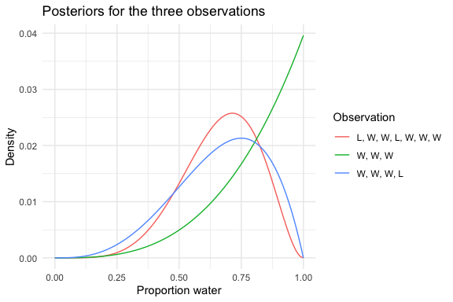

```r
grid_steps <- 100
data2M1 <-
 tibble(p_grid            = rep(seq(from = 0, to = 1, length.out = grid_steps), 3),
        prior             = 1,
        waters            = c(rep(3, grid_steps), rep(3, grid_steps), rep(5, grid_steps)),
        sizes             = c(rep(3, grid_steps), rep(4, grid_steps), rep(7, grid_steps)),
        Observation       = c(rep("W, W, W", grid_steps),
                              rep("W, W, W, L", grid_steps),
                              rep("L, W, W, L, W, W, W", grid_steps))) %>%
   group_by(Observation) %>%
   mutate(likelihood      = dbinom(waters, size = sizes , prob = p_grid)) %>%
   mutate(unstd_posterior = likelihood * prior) %>%
   mutate(posterior       = unstd_posterior / sum(unstd_posterior))

ggplot(data = data2M1, aes(x = p_grid, y = posterior, colour = Observation)) +
  geom_line() +
  labs(x = "Proportion water",
       y = "Density") +
  theme_minimal() +
  ggtitle("Posteriors for the three observations")
```

**2M2.** Now assume a prior for p that is equal to zero when p < 0.5 and is a positive constant when p ≥ 0.5. Again compute and plot the grid approximate posterior distribution for each of the sets of observations in the problem just above.

**SOLUTION**

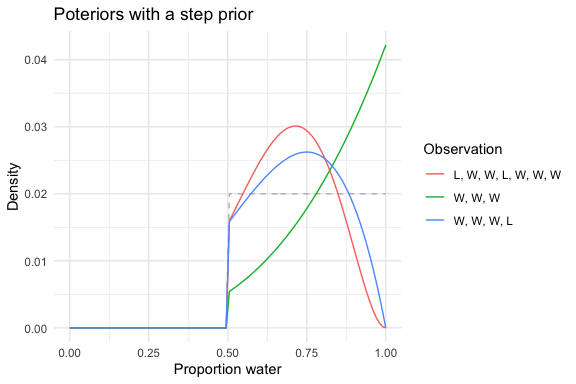

```r
grid_steps <- 100
data2M2 <-
 tibble(p_grid            = rep(seq(from = 0, to = 1, length.out = grid_steps), 3),
        prior             = if_else(p_grid<0.5, 0, 1) / (grid_steps/2),
        waters            = c(rep(3, grid_steps), rep(3, grid_steps), rep(5, grid_steps)),
        sizes             = c(rep(3, grid_steps), rep(4, grid_steps), rep(7, grid_steps)),
        Observation       = c(rep("W, W, W", grid_steps),
                              rep("W, W, W, L", grid_steps),
                              rep("L, W, W, L, W, W, W", grid_steps))) %>%
   group_by(Observation) %>%
   mutate(likelihood      = dbinom(waters, size = sizes , prob = p_grid)) %>%
   mutate(unstd_posterior = likelihood * prior) %>%
   mutate(posterior       = unstd_posterior / sum(unstd_posterior))

ggplot(data = data2M2, aes(x = p_grid, y = posterior, colour = Observation)) +
  geom_line(aes(y = prior), linetype = "dashed", colour = "grey") +
  geom_line() +
  labs(x = "Proportion water",
       y = "Density") +
  theme_minimal() +
  ggtitle("Poteriors with a step prior")
```

**2M3.** Suppose there are two globes, one for Earth and one for Mars. The Earth globe is 70% covered in water. The Mars globe is 100% land. Further suppose that one of these globes—you don’t know which—was tossed in the air and produced a “land” observation. Assume that each globe was equally likely to be tossed. Show that the posterior probability that the globe was the Earth, conditional on seeing “land” (Pr(Earth|land)), is 0.23.

**SOLUTION**

Since there is not know bias:

pr(Earth) = 0.5  
pr(Mars) = 1 - Pr(Earth) = 0.5

And, as there is 70% water over the earth surface:

pr(Land|Earth) = 0.3  
pr(Water|Earth) = 0.7

and 0% over martian surface:

pr(Land|Mars) = 1  
pr(Water|Mars) = 0

Then, using [Bayes Theorem](https://en.wikipedia.org/wiki/Bayes%27_theorem)

pr(Earth|Land) = pr(Land|Earth) pr(Earth) / pr(Land)  
pr(Earth|Land) = 0.3 0.5/0.65  
**pr(Earth|Land) = 0.23**

**2M4.** Suppose you have a deck with only three cards. Each card has two sides, and each side is either black or white. One card has two black sides. The second card has one black and one white side. The third card has two white sides. Now suppose all three cards are placed in a bag and shuffled. Someone reaches into the bag and pulls out a card and places it flat on a table. A black side is shown facing up, but you don’t know the color of the side facing down. Show that the probability that the other side is also black is 2/3. Use the counting method (Section 2 of the chapter) to approach this problem. This means counting up the ways that each card could produce the observed data (a black side facing up on the table).

**SOLUTION**

We will call the cards BB, BW and WW and, since we do not have any bias for picking a given card, the probabilities of picking each of them is the same: p(BB) = p(BW) = p(WW) = 1/3

*Using Bayes theorem:*

The probability of getting a BB card given that the side facing upwards is black can be rewritten as

p(BB|B) = p(B|BB) p(BB) / p(B)

Where we know that p(BB) = 1/3

The conditional probabilities can be defined if we have in mind the forking paths. Theres are two ways to get a black side with a BB card, one way with a BW card and zero ways with a WW card. So, if the card is BB, the probability of getting a B side is 1 while if the card is CW this goes down to 1/2.

p(B|BB) = 1  
p(B|BW) = 1/2  
p(B|WW) = 0

OK, so now the only thing we should deal with before being able to calculate the probability is p(B). P(B) is basically all the possible combinations in which we could obtain a black card and can be calculated as:

p(B) = p(B|BB) p(BB) + p(B|BW) p(BW) + p(B|WW) p(WW)  
p(B) = 1 1/3 + 1/2 1/3 + 0 1/3  
p(B) = 1/2

Then, putting all together:

p(BB|B) = p(B|BB) p(BB) / p(B)  
p(BB|B) = 1 1/3 / (1/2)  
**p(BB|B) = 2/3**

**2M5.** Now suppose there are four cards: B/B, B/W, W/W, and another B/B. Again suppose a card is drawn from the bag and a black side appears face up. Again calculate the probability that the other side is black.

**SOLUTION**

*Forking paths:*

Now the possible ways in which the card could be BB are four (side one and two of each BB card) while the ways in which the card could be BW remains one. That is why the probability of the card being black on both sides given that the onward face is black is four out of five (*p(BB|B)=4/5*).

*Using Bayes theorem:*

Now what changes is the probabilty of picking a given card: p(BB) = 1/2  
p(BW) = p(WW) = 1/4

and P(B) becomes:

p(B) = p(B|BB) p(BB) + p(B|BW) p(BW) + p(B|WW) p(WW)  
p(B) = 1 1/2 + 1/2 1/4 + 0 1/4  
p(B) = 5/8

Finally:

p(BB|B) = p(B|BB) p(BB) / p(B)  
p(BB|B) = 1 1/2 / (5/8)  
**p(BB|B) = 4/5 = 0.8**

**2M6.** Imagine that black ink is heavy, and so cards with black sides are heavier than cards with white sides. As a result, it’s less likely that a card with black sides is pulled from the bag. So again assume there are three cards: B/B, B/W, and W/W. After experimenting a number of times, you conclude that for every way to pull the B/B card from the bag, there are 2 ways to pull the B/W card and 3 ways to pull the W/W card. Again suppose that a card is pulled and a black side appears face up. Show that the probability the other side is black is now 0.5. Use the counting method, as before.

**SOLUTION**

*Forking paths:*

Now, in the long run, for each six draws there will be one BB card, two BW cards and three WW cards. This means that out seeing a black side facing upwards is compatible with four possible configurations (the two sides of BB plus the two different draws of BW). Out of this four possible configurations only two are compatible with the card begin BB, giving us a probability of having a BB card of two out of four (*p(BB|B)=1/2*).

*Using Bayes theorem:*

Again what changes is the probabilty of picking a given card: p(BB) = 1/6  
p(BW) = 2/6 = 1/3  
p(WW) = 3/6 = 1/2

and P(B) becomes:

p(B) = p(B|BB) p(BB) + p(B|BW) p(BW) + p(B|WW) p(WW)  
p(B) = 1 1/6 + 1/2 1/3 + 0 1/2  
p(B) = 2/6 = 1/3

Finally:

p(BB|B) = p(B|BB) p(BB) / p(B)  
p(BB|B) = 1 1/6 / (1/3)  
**p(BB|B) = 1/2 = 0.5**

**2M7.** Assume again the original card problem, with a single card showing a black side face up. Before looking at the other side, we draw another card from the bag and lay it face up on the table. The face that is shown on the new card is white. Show that the probability that the first card, the one showing a black side, has black on its other side is now 0.75. Use the counting method, if you can. Hint: Treat this like the sequence of globe tosses, counting all the ways to see each observation, for each possible first card.

**SOLUTION**

Let’s count! First, if the first card shows a black face upwards we cab be either with a BB or a BW cardon the table. The probability of being BB is two out of three (two sides of BB and one side of BW). Next, let’s assume we picked the BB, then we have six possible combinations that are compatible:

side one of BB -> white side of BW  
side one of BB -> side one of WW  
side one of BB -> side two of WW

side two of BB -> white side of BW  
side two of BB -> side one of WW  
side two of BB -> side two of WW

And, on the other hand, if we picked the BW card, thete is only two possible second draws that are compatible with the sequence black-white:

black side of BW -> side one of WW  
black side of BW -> side two of WW

If we count, we can add up the probability of being BB with the sequence of balc and white sides facing upwards (and no replacement) is 6 out of 8, or 75%.

## Hard

**2H1.** Suppose there are two species of panda bear. Both are equally common in the wild and live in the same places. They look exactly alike and eat the same food, and there is yet no genetic assay capable of telling them apart. They differ however in their family sizes. Species A gives birth to twins 10% of the time, otherwise birthing a single infant. Species B births twins 20% of the time, otherwise birthing singleton infants. Assume these numbers are known with certainty, from many years of field research.  
Now suppose you are managing a captive panda breeding program. You have a new female panda of unknown species, and she has just given birth to twins. What is the probability that her next birth will also be twins?

**2H2.** Recall all the facts from the problem above. Now compute the probability that the panda we have is from species A, assuming we have observed only the first birth and that it was twins.

**2H3.** Continuing on from the previous problem, suppose the same panda mother has a second birth and that it is not twins, but a singleton infant. Compute the posterior probability that this panda is species A.

**2H4.** A common boast of Bayesian statisticians is that Bayesian inference makes it easy to use all of the data, even if the data are of different types. So suppose now that a veterinarian comes along who has a new genetic test that she claims can identify the species of our mother panda. But the test, like all tests, is imperfect. This is the information you have about the test:

- The probability it correctly identifies a species A panda is 0.8.
- The probability it correctly identifies a species B panda is 0.65.

The vet administers the test to your panda and tells you that the test is positive for species A. First ignore your previous information from the births and compute the posterior probability that your panda is species A. Then redo your calculation, now using the birth data as well.